# Practical Machine Learning

## Preprocessing with principal component analysis

When you have lots of correlated explanatory variables. You may want to use a variable that acts as a summary of those variables.

```r
data(spam)
inTrain <- createDataPartition(y=spam$type,p=0.75,list=FALSE)

training <- spam[inTrain,]
testing <- spam[-inTrain,]

M <- abs(cor(training[,-58]))
diag(M) <- 0
which(M > 0.8, arr.ind=T)
```

```
##        row col
## num415  34  32
## direct  40  32
## num857  32  34
## direct  40  34
## num857  32  40
## num415  34  40
```

```r
names(spam)[c(34,32)]
```

```
## [1] "num415" "num857"
```

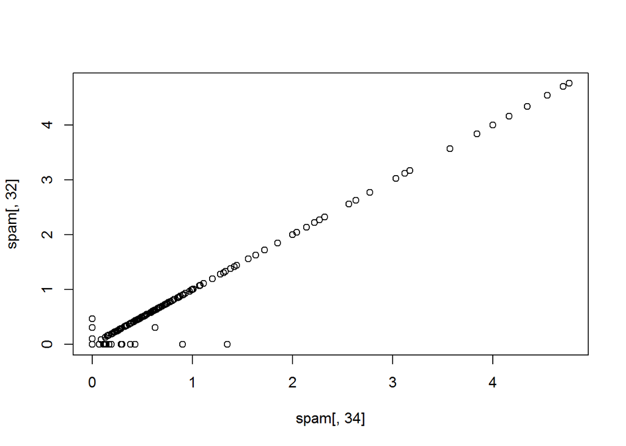

```r
plot(spam[,34],spam[,32])
```

### The Basic Idea

- Make a weighted combination of the highly correlated variables that captures as much of the information as possible.

### Related Problems

- Find a new set of multivariate variables that are uncorrelated and explain as much of the variance as possible.
- If you put all the variables together in one matrix, find the best matrix created with fewer variables (lower rank) that explains the original data.

The first goal is *statistical* the second goal is *data compression*

### There are two related solutions: Singular Value Decomposition and Principal Components Analysis

**SVD**

If X is a matrix with each variable in a column and each observation in a row, then the SVD is a “matrix decomposition”

$X = UDV^T$

where the columns of *U* are orthogonal (left singular vectors), the columns of *V* are orthogonal (right singular vectors) and *D* id a diagonal matrix (singular values).

**PCA**

The principal components are equal to the right singular values if you first scale (subtract mean, divide by sd) the variables.

### Principal components in R - prcomp

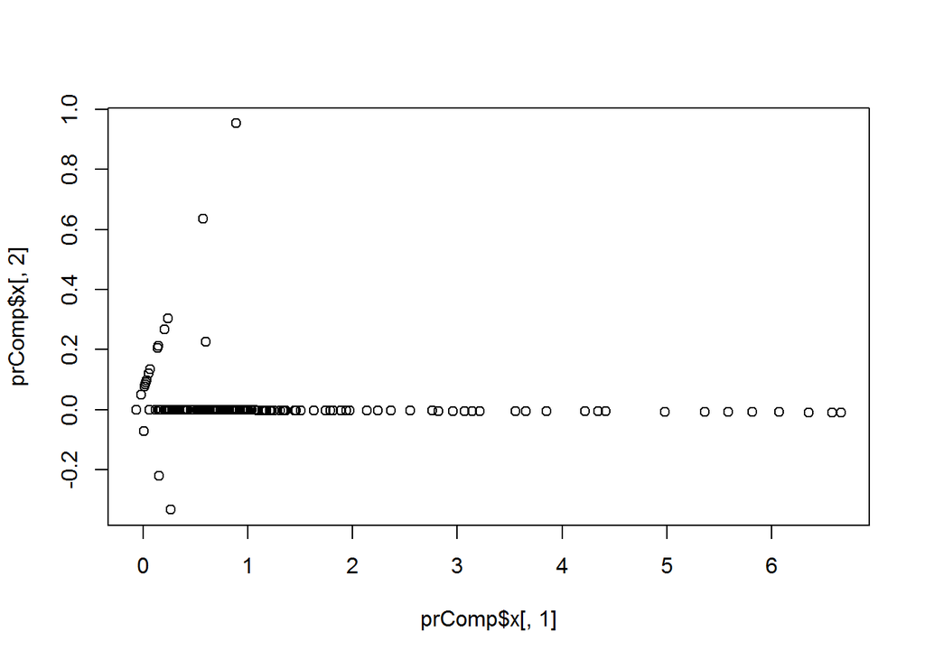

```r
smallSpam <- spam[,c(34,32)]
prComp <- prcomp(smallSpam)
plot(prComp$x[,1],prComp$x[,2])
```

The rotation matrix tells you how it’s summing up the two components to get the new variables.

```r
prComp$rotation
```

```
##              PC1        PC2
## num415 0.7080625  0.7061498
## num857 0.7061498 -0.7080625
```

So, principal component 1 is just the sum of 0.7081 x num415 and 0.7061 x num857, principal component 2 is subtracting 0.7081 x num857 from 0.7061 x num415.

### PCA on SPAM data

We do PCA on the entire SPAM dataset, taking the log of the variables and adding one. The reason for this is that some of the variables are highly skewed and it’s important to have normal-looking variables for PCA.

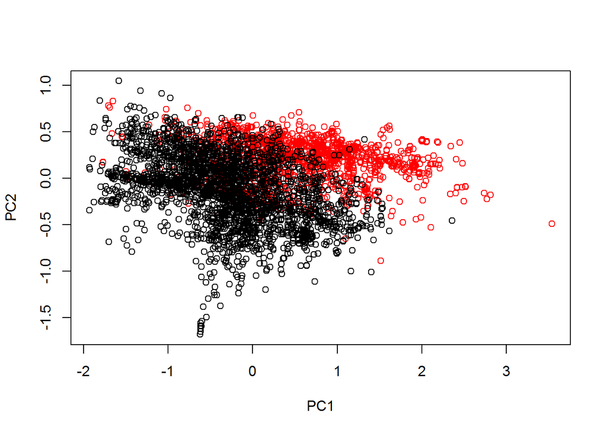

```r
typeColor <- ((spam$type=="spam")*1 + 1)
prComp <- prcomp(log10(spam[,-58] + 1))
plot(prComp$x[,1],prComp$x[,2],col=typeColor,xlab="PC1",ylab="PC2")
```

Now, PC1 and PC2 are no longer combinations of just 2 variables, they are a complicated combination of the variables in the data set.

What we can see is that there is some difference between PC1 and PC2 with regard the Spam vs. Ham data.

### PCA with the caret package

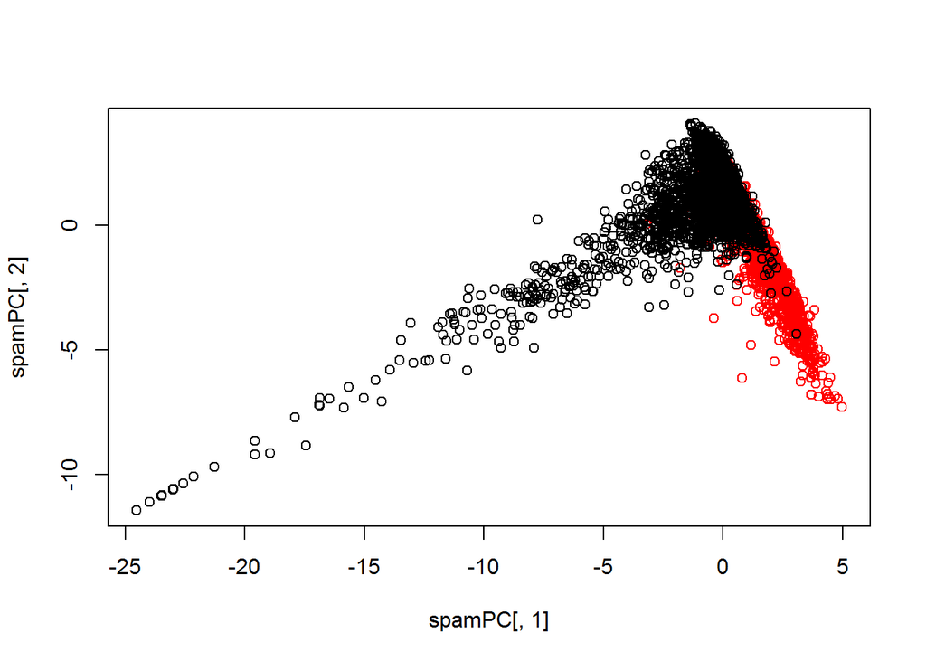

```r
preProc <- preProcess(log10(spam[,-58]+1),method="pca",pcaComp=2)
spamPC <- predict(preProc,log10(spam[,-58]+1))
plot(spamPC[,1],spamPC[,2],col=typeColor)
```

*pcaComp* allows you to tell the function what number of principal components you want.

You can use the Principal Components in a model this way:

```r
preProc <- preProcess(log10(training[,-58]+1), method="pca",pcaComp=2)
trainPC <- predict(preProc,log10(training[,-58]+1))
 modelFit <- train(training$type ~., method="glm", data=trainPC)
```

When you apply to the test data, you have to use the same variables that you calculated for the training data, so pass *predict* the same *preProc* object that you created in the training set, but pass in the log-transformed testing data.

```r
testPC <- predict(preProc, log10(testing[,-58]+1))
confusionMatrix(testing$type, predict(modelFit,testPC))
```

```
## Confusion Matrix and Statistics
##
##           Reference
## Prediction nonspam spam
##    nonspam     645   52
##    spam         73  380
##
##                Accuracy : 0.8913
##                  95% CI : (0.8719, 0.9087)
##     No Information Rate : 0.6243
##     P-Value [Acc > NIR] : < 2e-16
##
##                   Kappa : 0.7705
##  Mcnemar's Test P-Value : 0.07364
##
##             Sensitivity : 0.8983
##             Specificity : 0.8796
##          Pos Pred Value : 0.9254
##          Neg Pred Value : 0.8389
##              Prevalence : 0.6243
##          Detection Rate : 0.5609
##    Detection Prevalence : 0.6061
##       Balanced Accuracy : 0.8890
##
##        'Positive' Class : nonspam
##
```

Notice you’re passing confusionMatrix the function predict that has the modelFit from the training step, with the Principal components from the test data.

### If you don’t want to set the number of PCs

```r
modelFit <- train(training$type~.,method="glm", preProcess="pca",data=training)
confusionMatrix(testing$type,predict(modelFit,testing))
```

```
## Confusion Matrix and Statistics
##
##           Reference
## Prediction nonspam spam
##    nonspam     658   39
##    spam         50  403
##
##                Accuracy : 0.9226
##                  95% CI : (0.9056, 0.9374)
##     No Information Rate : 0.6157
##     P-Value [Acc > NIR] : <2e-16
##
##                   Kappa : 0.8372
##  Mcnemar's Test P-Value : 0.2891
##
##             Sensitivity : 0.9294
##             Specificity : 0.9118
##          Pos Pred Value : 0.9440
##          Neg Pred Value : 0.8896
##              Prevalence : 0.6157
##          Detection Rate : 0.5722
##    Detection Prevalence : 0.6061
##       Balanced Accuracy : 0.9206
##
##        'Positive' Class : nonspam
##
```

### Final Thoughts on PCA

- It’s most useful for linear-type models
- It can make the interpretation of predictors very difficult
- Outliers can really screw things up so
  - Transform your data first, either with log or BoxCox transform
  - Plot predictors to identify potential problems
- For more info, check out the EDA course or Elements of Statistical Learning.

## Predicting with Regression

**Pros**

- Easy to interpret
- Easy to implement

**Cons**

- Performs poorly in non-linear data settings.

### Example: Old Faithful Eruptions

```r
data(faithful);set.seed(333)
inTrain <- createDataPartition(y=faithful$waiting,p=0.5,list=FALSE)
trainFaith <- faithful[inTrain,]
testFaith <- faithful[-inTrain,]
head(trainFaith)
```

```
##    eruptions waiting
## 6      2.883      55
## 11     1.833      54
## 16     2.167      52
## 19     1.600      52
## 22     1.750      47
## 27     1.967      55
```

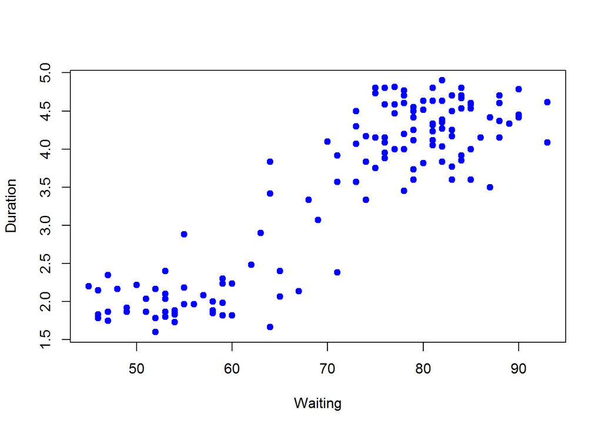

```r
plot(trainFaith$waiting, trainFaith$eruptions,pch=19,col="blue",xlab="Waiting",ylab="Duration")
```

### Fitting a linear model

$ED_i = b_0 + b_1 WT_i + e_i$

```r
lm1 <- lm(eruptions ~ waiting, data=trainFaith)
summary(lm1)
```

```
##
## Call:
## lm(formula = eruptions ~ waiting, data = trainFaith)
##
## Residuals:
##      Min       1Q   Median       3Q      Max
## -1.26990 -0.34789  0.03979  0.36589  1.05020
##
## Coefficients:
##              Estimate Std. Error t value Pr(>|t|)
## (Intercept) -1.792739   0.227869  -7.867 1.04e-12 ***
## waiting      0.073901   0.003148  23.474  < 2e-16 ***
## ---
## Signif. codes:  0 '***' 0.001 '**' 0.01 '*' 0.05 '.' 0.1 ' ' 1
##
## Residual standard error: 0.495 on 135 degrees of freedom
## Multiple R-squared:  0.8032, Adjusted R-squared:  0.8018
## F-statistic:   551 on 1 and 135 DF,  p-value: < 2.2e-16
```

### Predict a new variable

```r
coef(lm1)[1] + coef(lm1)[2]*80
```

```
## (Intercept)
##    4.119307
```

```r
newdata <- data.frame(waiting=80)
predict(lm1,newdata)
```

```
##        1
## 4.119307
```

### Plotting predictions: training and testing

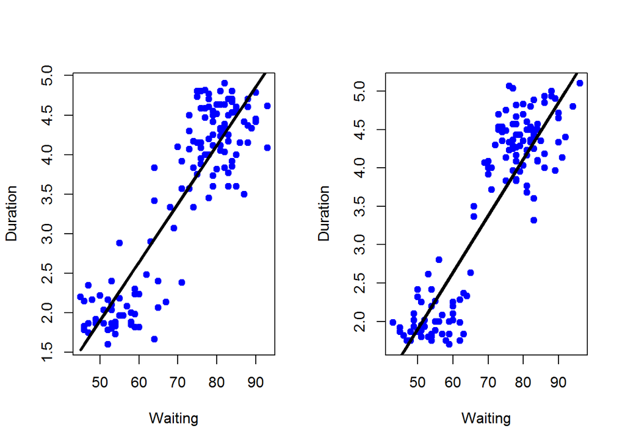

```r
par(mfrow=c(1,2))
plot(trainFaith$waiting,trainFaith$eruptions,pch=19,col="blue",xlab="Waiting",ylab="Duration")
lines(trainFaith$waiting,predict(lm1),lwd=3)
plot(testFaith$waiting,testFaith$eruptions, pch=19,col="blue",xlab="Waiting",ylab="Duration")

lines(testFaith$waiting,predict(lm1,newdata=testFaith),lwd=3)
```

### Get training/test set errors

```r
# Calculate RMSE on training set
sqrt(sum((lm1$fitted-trainFaith$eruptions)^2))
```

```
## [1] 5.75186
```

```r
# and on test set
sqrt(sum((predict(lm1,newdata=testFaith)-testFaith$eruptions)^2))
```

```
## [1] 5.838559
```

### Prediction Intervals

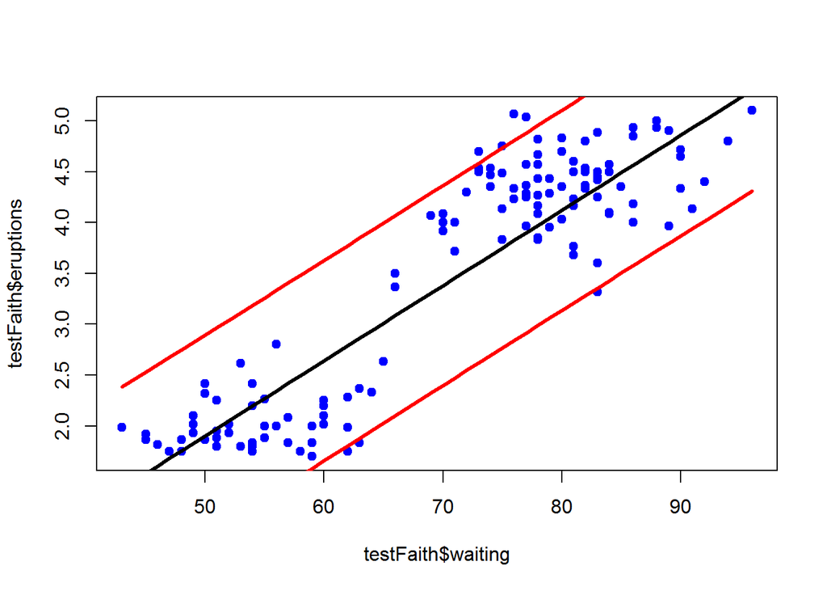

```r
pred1 <- predict(lm1,newdata=testFaith, interval="prediction")
ord <- order(testFaith$waiting)
plot(testFaith$waiting, testFaith$eruptions,pch=19,col="blue")
matlines(testFaith$waiting[ord],pred1[ord,],type="l",,col=c(1,2,2),lty=c(1,1,1),lwd=3)
```

### Same Process with caret package

```r
modFit <- train(eruptions ~waiting, data=trainFaith,method="lm")
summary(modFit$finalModel)
```

```
##
## Call:
## lm(formula = .outcome ~ ., data = dat)
##
## Residuals:
##      Min       1Q   Median       3Q      Max
## -1.26990 -0.34789  0.03979  0.36589  1.05020
##
## Coefficients:
##              Estimate Std. Error t value Pr(>|t|)
## (Intercept) -1.792739   0.227869  -7.867 1.04e-12 ***
## waiting      0.073901   0.003148  23.474  < 2e-16 ***
## ---
## Signif. codes:  0 '***' 0.001 '**' 0.01 '*' 0.05 '.' 0.1 ' ' 1
##
## Residual standard error: 0.495 on 135 degrees of freedom
## Multiple R-squared:  0.8032, Adjusted R-squared:  0.8018
## F-statistic:   551 on 1 and 135 DF,  p-value: < 2.2e-16
```

## Predicting with Regression, using Multiple Covariates

### Example: predicting wages

```r
data(Wage)
Wage <- subset(Wage,select=-c(logwage))
summary(Wage)
```

```
##       year           age               sex                    maritl
##  Min.   :2003   Min.   :18.00   1. Male  :3000   1. Never Married: 648
##  1st Qu.:2004   1st Qu.:33.75   2. Female:   0   2. Married      :2074
##  Median :2006   Median :42.00                    3. Widowed      :  19
##  Mean   :2006   Mean   :42.41                    4. Divorced     : 204
##  3rd Qu.:2008   3rd Qu.:51.00                    5. Separated    :  55
##  Max.   :2009   Max.   :80.00
##
##        race                   education                     region
##  1. White:2480   1. < HS Grad      :268   2. Middle Atlantic   :3000
##  2. Black: 293   2. HS Grad        :971   1. New England       :   0
##  3. Asian: 190   3. Some College   :650   3. East North Central:   0
##  4. Other:  37   4. College Grad   :685   4. West North Central:   0
##                  5. Advanced Degree:426   5. South Atlantic    :   0
##                                           6. East South Central:   0
##                                           (Other)              :   0
##            jobclass               health      health_ins
##  1. Industrial :1544   1. <=Good     : 858   1. Yes:2083
##  2. Information:1456   2. >=Very Good:2142   2. No : 917
##
##
##
##
##
##       wage
##  Min.   : 20.09
##  1st Qu.: 85.38
##  Median :104.92
##  Mean   :111.70
##  3rd Qu.:128.68
##  Max.   :318.34
##
```

### Get training and test sets

```r
inTrain <- createDataPartition(y=Wage$wage,p=0.7,list=FALSE)
training <- Wage[inTrain,]
testing <- Wage[-inTrain,]
dim(training)
```

```
## [1] 2102   11
```

```r
dim(testing)
```

```
## [1] 898  11
```

### Feature Plot

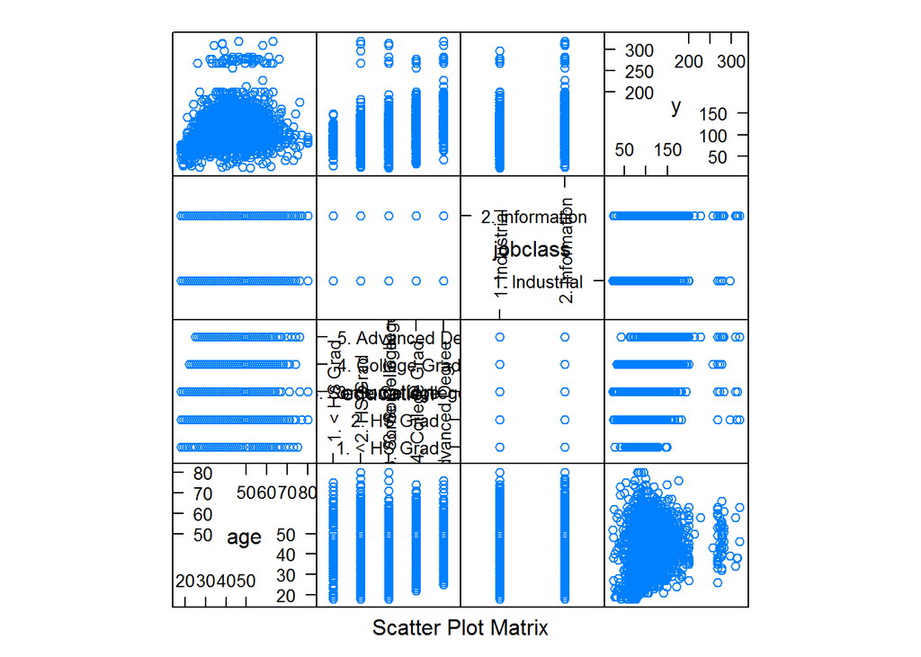

```r
featurePlot(x=training[,c("age","education","jobclass")],y=training$wage,plot="pairs")
```

This plot shows you that there are two different values for the outcome variable based on the levels of *jobclass*. One level of *jobclass* has higher *wage* and one has lower *wage*. So, any pattern you see here is relative to the *wage* variable and may be a good choice of predictor.

### Plot age vs. wage

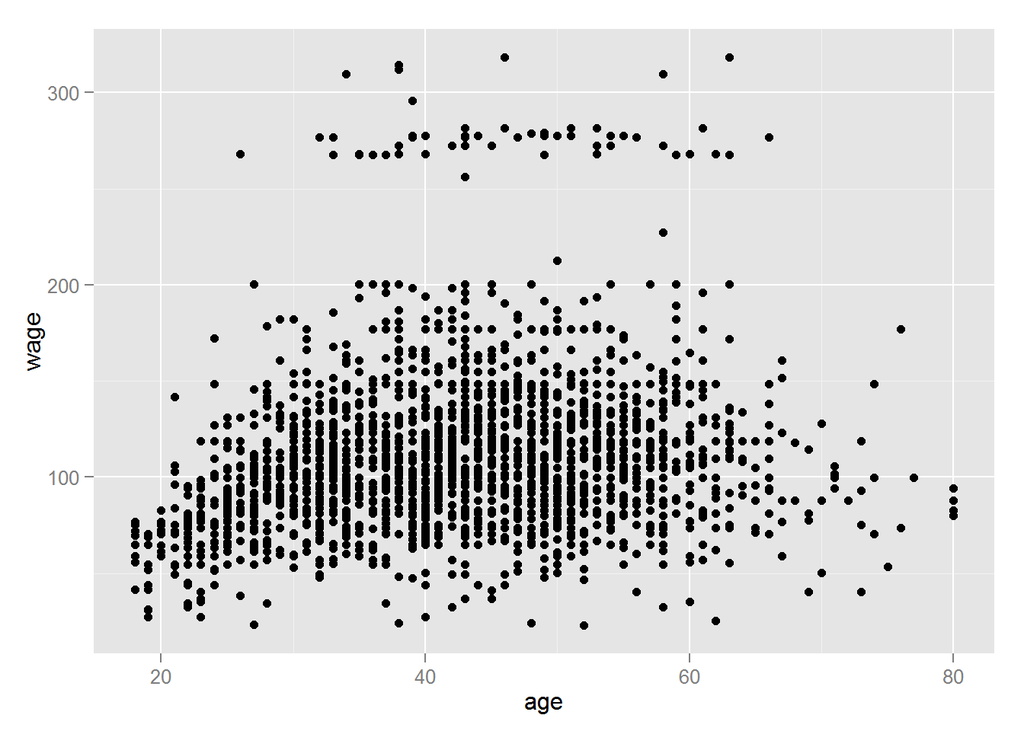

```r
qplot(age,wage,data=training)
```

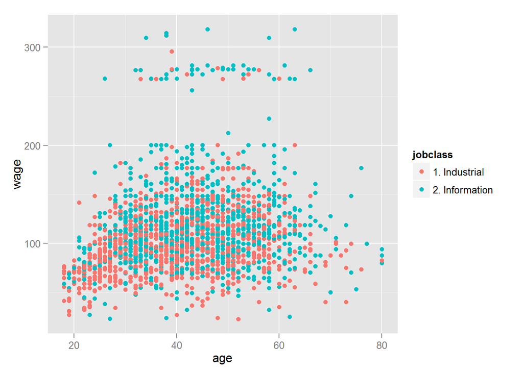

```r
qplot(age,wage,color=jobclass,data=training)
```

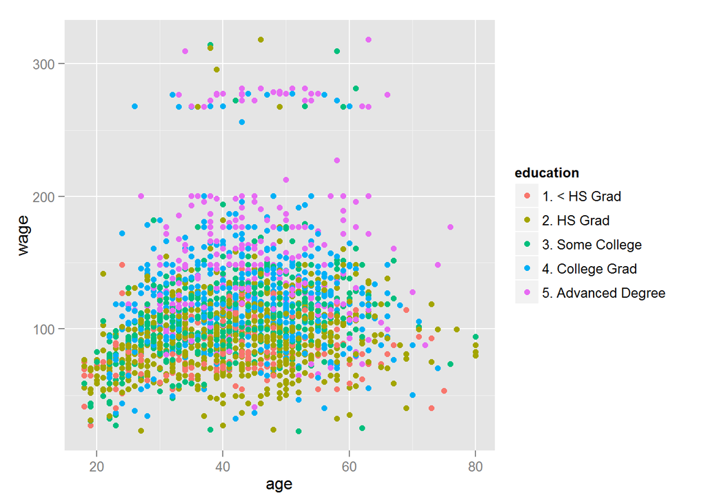

```r
qplot(age,wage,color=education,data=training)
```

So advanced degree and job class explain some of the outliers in the relationship between age and wage.

### Fit a linear model

$ED_i = b_0 +b_1 age + b_2 I(Jobclass_i = "Information") + \sum_{k=1}^{4}\gamma_k I(education_i = levelk)$

```r
modFit <- train(wage ~ age + jobclass + education, method="lm",data=training)
finMod <- modFit$finalModel
print(modFit)
```

```
## Linear Regression
##
## 2102 samples
##   10 predictor
##
## No pre-processing
## Resampling: Bootstrapped (25 reps)
##
## Summary of sample sizes: 2102, 2102, 2102, 2102, 2102, 2102, ...
##
## Resampling results
##
##   RMSE      Rsquared   RMSE SD   Rsquared SD
##   36.88938  0.2475448  1.418546  0.02422147
##
##
```

### Diagnostics

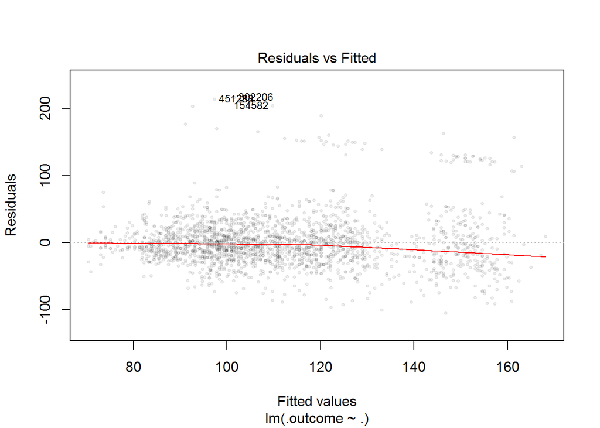

```r
plot(finMod,1,pch=19,cex=0.5,col="#00000010")
```

Plots the fitted values vs. the residuals. You want to see a nice straight line at zero. There are a few outliers which we might want to explore a solution for.

### Color the plot by variables not used in the model

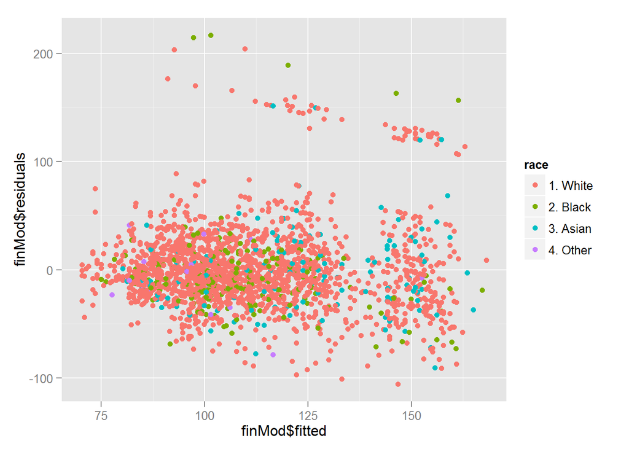

```r
qplot(finMod$fitted,finMod$residuals,color=race,data=training)
```

So, some of the outliers may be explained by the race variable.

### Plot residuals by index

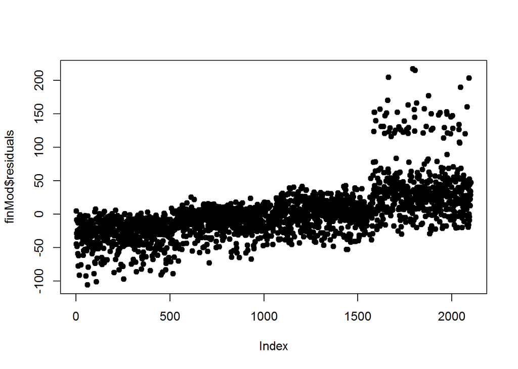

```r
plot(finMod$residuals,pch=19)
```

There’s a trend with respect to the row numbers and a lot more at the end. There may be a relationship with respect to time or age or some other continuous variable.

### Predicted vs. true values in test set

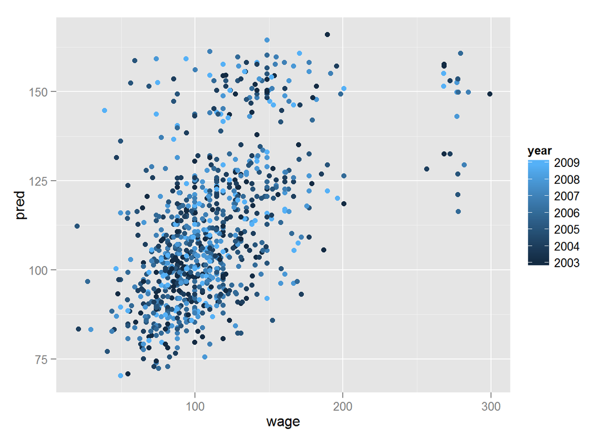

```r
pred <- predict(modFit, testing)
qplot(wage, pred, colour=year, data=testing)
```

You would only do this at the end. You can’t go back and tweak your training model based on this. It just tells you what happened with your model.

### If you want to use all covariates, use the period

```r
modFitAll <- train(wage~.,data=training, method="lm")
pred <- predict(modFitAll, testing)
```

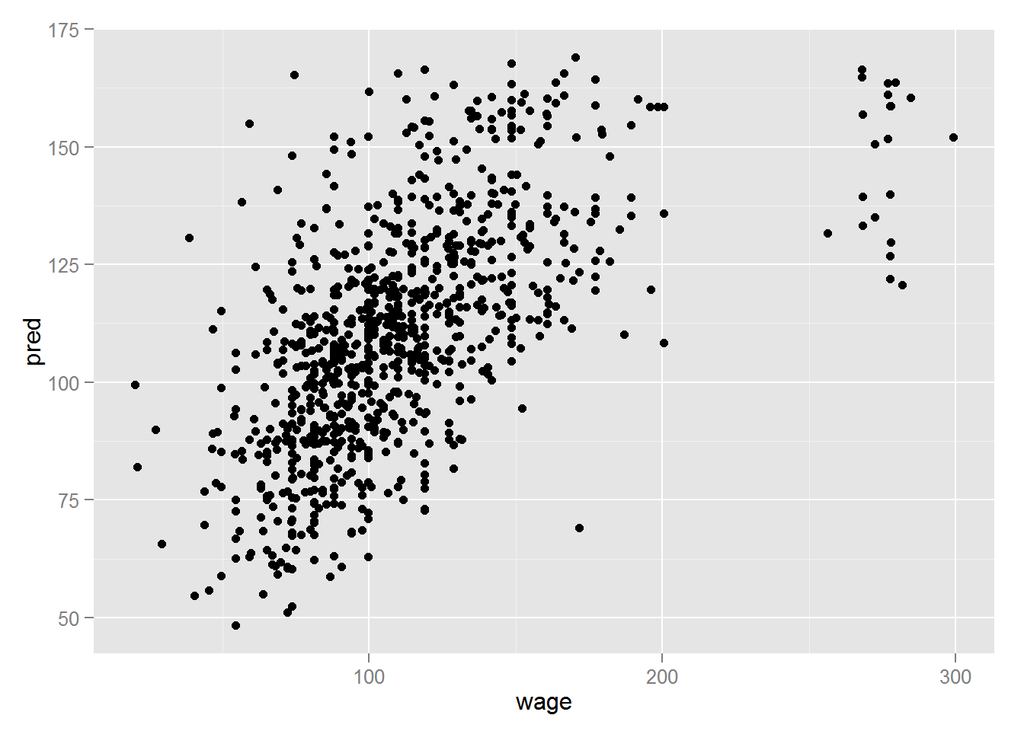

```r
qplot(wage, pred, data=testing)
```

Week 3

## Predicting with Trees

### Key ideas

- Iteratively split variables into groups
- Evaluate “homogeneity” within each group
- Split multiple times if necessary
- until you get outcomes that are “homogeneous enough”

**Pros**

- Easy to interpret
- Better performance in nonlinear settings

**Cons**

- Without pruning/cross-validation can lead to overfitting
- Harder to estimate uncertainty
- Results may vary

### Basic algorithm

1. Start with all variables as part of one group
2. Find the variable/split that best separates the outcomes
3. Divide the data into two groups (“leaves”) on that split (“node”)
4. Within each split, find the best variable/split that separates the outcomes
5. Continue until the groups are too small or sufficiently “pure”

### Measures of impurity

m: leaf, k: class

$\hat{p}_{mk} = \frac{1}{N_m} \sum_{x_i in leaf m} I(y_i = k)$

**Misclassification Error**

$1- \hat{p}_{mk(m)} // k(m) = most.common.k$

0: no misclassification error (perfect purity)

0.5: no purity

**Gini index**

$\sum_{k\ne k'} \hat{p}_{mk} x \hat{p}_{mk'} = \sum_{k=1}^K \hat{p}_{mk} (1-\hat{p}_{mk}) = 1 - \sum_{k=1}^K p_{mk}^2$

0: no misclassification error (perfect purity)

0.5: no purity

**Deviance/Information Gain**

$- \sum_{k=1}^K \hat{p}_{mk} log_2\hat{p}_{mk}$

0: perfect purity

1: no purity

If log is in base $e$, it’s deviance. If base $2$, it’s Information Gain.

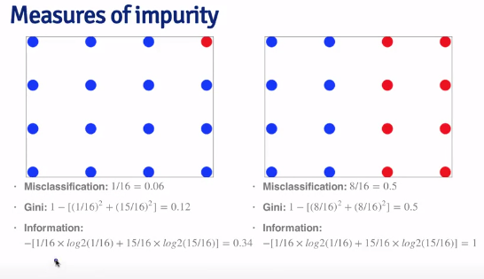

So, each box represents a leaf. In the first box, 15 were classified correctly, 1 was classified incorrectly. In the second box, 8 were classified correctly and 8 were classified incorrectly.

### Example: Iris Data

```r
data(iris)
names(iris)
```

```
## [1] "Sepal.Length" "Sepal.Width"  "Petal.Length" "Petal.Width"
## [5] "Species"
```

```r
table(iris$Species)
```

```
##
##     setosa versicolor  virginica
##         50         50         50
```

#### Create training and test sets

```r
inTrain <- createDataPartition(y=iris$Species, p=0.7, list=FALSE)
training <- iris[inTrain,]
testing <- iris[-inTrain,]
dim(training);dim(testing)
```

```
## [1] 105   5
```

```
## [1] 45  5
```

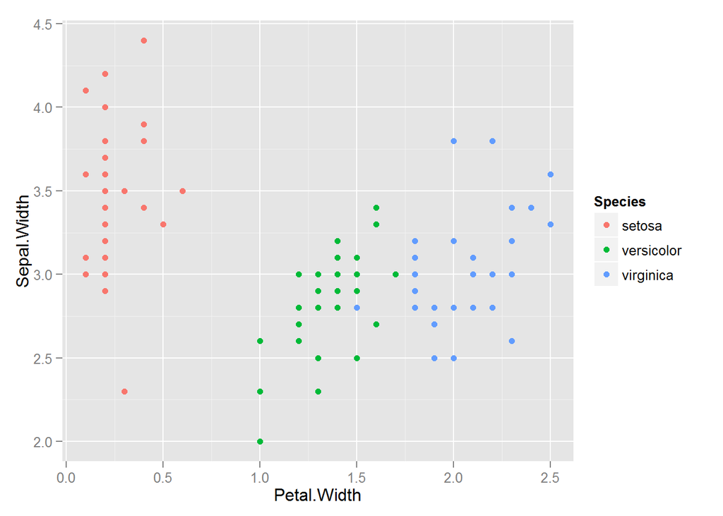

```r
qplot(Petal.Width, Sepal.Width, colour=Species, data=training)
```

```r
modFit <- train(Species ~., method="rpart",data=training)
print(modFit$finalModel)
```

```
## n= 105
##
## node), split, n, loss, yval, (yprob)
##       * denotes terminal node
##
## 1) root 105 70 setosa (0.33333333 0.33333333 0.33333333)
##   2) Petal.Length< 2.6 35  0 setosa (1.00000000 0.00000000 0.00000000) *
##   3) Petal.Length>=2.6 70 35 versicolor (0.00000000 0.50000000 0.50000000)
##     6) Petal.Width< 1.75 35  1 versicolor (0.00000000 0.97142857 0.02857143) *
##     7) Petal.Width>=1.75 35  1 virginica (0.00000000 0.02857143 0.97142857) *
```

[figure not shown]

```r
plot(modFit$finalModel, uniform=TRUE, main="Classification Tree")
```

```r
library(rattle)
```

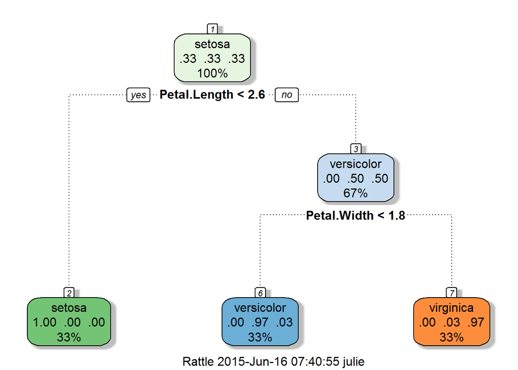

```r
fancyRpartPlot(modFit$finalModel)
```

### Predicting new values

```r
predict(modFit,newdata=testing)
```

```
##  [1] setosa     setosa     setosa     setosa     setosa     setosa
##  [7] setosa     setosa     setosa     setosa     setosa     setosa
## [13] setosa     setosa     setosa     versicolor versicolor versicolor
## [19] versicolor versicolor versicolor versicolor versicolor versicolor
## [25] versicolor versicolor versicolor versicolor versicolor versicolor
## [31] versicolor virginica  virginica  virginica  virginica  versicolor
## [37] virginica  virginica  versicolor versicolor virginica  virginica
## [43] virginica  virginica  virginica
## Levels: setosa versicolor virginica
```

### Notes and further resources

- Classification trees are non-linear models
- They use interactions between variables
- Data transformations are not so important (especially ones that maintain the order of the data, monotone transformations)
- Trees can also be used for continuous outcomes
- There are multiple tree building options in R in the caret packages: **party**, **rpart** and **tree** (tree is not in the caret package)
- See Intro to statistical learning and elements of statistical learning

## Bagging

Short for *bootstrap aggregating*. A model averaging technique.

**Basic idea**

1. Resample cases with replacement and recalculate predictions
2. Take an average or majority vote

**Notes**

- Similar Bias
- But, reduced variance
- More useful for non-linear functions

```r
library(ElemStatLearn); data(ozone, package="ElemStatLearn")
ozone <- ozone[order(ozone$ozone),]
head(ozone)
```

```
##     ozone radiation temperature wind
## 17      1         8          59  9.7
## 19      4        25          61  9.7
## 14      6        78          57 18.4
## 45      7        48          80 14.3
## 106     7        49          69 10.3
## 7       8        19          61 20.1
```

Try to predict temperature as a function of ozone.

### Bagged Loess

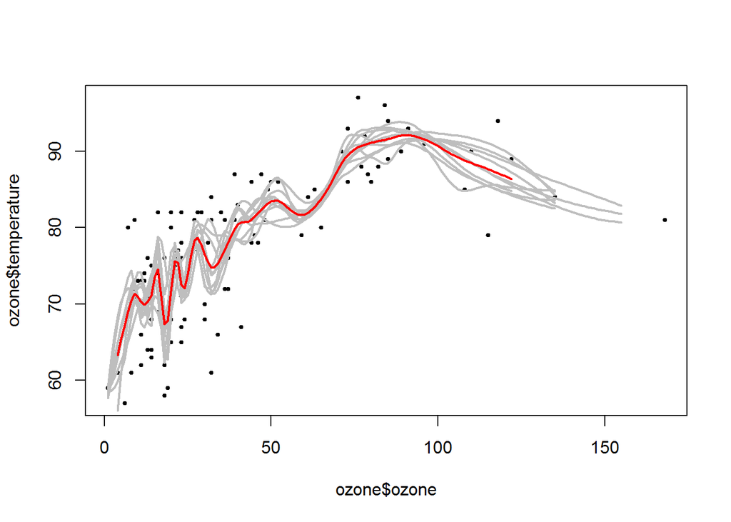

```r
ll <- matrix(NA, nrow=10,ncol=155)
for(i in 1:10){
  ss <- sample(1:dim(ozone)[1], replace=T) #sample from the data set with replacement
  ozone0 <- ozone[ss,]; ozone0 <- ozone0[order(ozone0$ozone),] #create a new dataset on the sample, reorder by ozone
  loess0 <- loess(temperature ~ ozone, data=ozone0,span=0.2) # fitting a loess curve, very similar to spline model fits that we saw with linear regression, span measures how smooth the fit will be
  ll[i,] <- predict(loess0, newdata=data.frame(ozone=1:155)) #then save the predicted values for averaging later
}
 plot(ozone$ozone, ozone$temperature, pch=19, cex=0.5)
  for(i in 1:10){lines(1:155, ll[i,],col="grey",lwd=2)}
  lines(1:155, apply(ll,2,mean),col="red",lwd=2)
```

Red is the average loess curve.

### Bagging in caret

- Some models perform bagging for you, in the **train** function, there are method options:
- bagEarth
- treeBag
- bagFDA
- Alternatively you can bag any model you choose using the **bag** function.

```r
predictors <- data.frame(ozone=ozone$ozone)
temperature <- ozone$temperature
treebag <- bag(predictors, temperature, B= 10,
               bagControl=bagControl(fit=ctreeBag$fit,
               predict=ctreeBag$pred,
               aggregate=ctreeBag$aggregate))
```

**bag** function: B is the number of subsamples you want to take. bagControl describes how to fit the model. ctree fits a conditional regression tree.

```r
ctreeBag$fit
```

```
## function (x, y, ...)
## {
##     library(party)
##     data <- as.data.frame(x)
##     data$y <- y
##     ctree(y ~ ., data = data)
## }
## <environment: namespace:caret>
```

So, now when we plot:

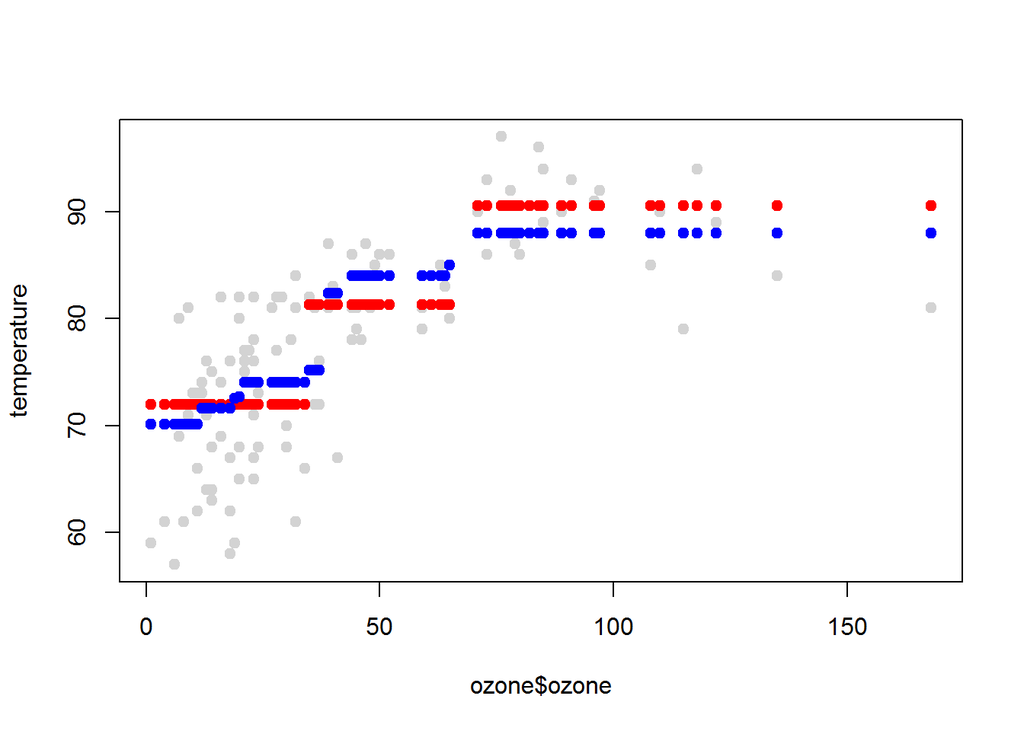

```r
plot(ozone$ozone, temperature, col='lightgrey', pch=19)
points(ozone$ozone, predict(treebag$fits[[1]]$fit, predictors),pch=19,col="red")
points(ozone$ozone, predict(treebag,predictors),pch=19,col="blue")
```

### Notes and Further Resources

- Bagging is most useful for nonlinear models
- Often used with trees, an extension is random forests
- Several models use bagging in caret’s *train* function
- See *Elements of Statistical Learning*

Stopped at end of Bagging

Quiz Answers